# Estudio Contaminantes Conjunto

2025-05-21

```r
library(dplyr)
library(tidyr)
library(ggplot2)
library(naniar)
library(lubridate)
library(zoo)
library(stringr)
library(emmeans)
library(forecast)
library(car)
library(lmtest)
library(emmeans)
library(mice)
library(FactoMineR)
library(factoextra)
library(pcaMethods)
library(tibble)
library(cluster)
library(pheatmap)
```

```r
df <- read.csv("~/Documents/Drive/UPV/Segundo/2ºCuatri/Proyecto/base_para_obj1.csv", stringsAsFactors = FALSE)
df <- df %>%
  mutate(FechaHora = ymd_hms(paste(Fecha, Hora, "00", "00", sep = ":"), tz = "UTC"))
df$Origen <- as.factor(df$Origen)
```

# 1 Selección de variables

Para este análsis vamos a utilizar las variables de interés que son las siguientes:

- FechaHora
- Origen
- $NO$
- $NO_2$
- $NO_x$
- $O_3$
- $PM_{10}$
- $PM_{2.5}$
- $SO_2$

```r
df <- df %>%
  select(FechaHora, Origen, NO, NO2, NOx, O3, PM10, PM2.5, SO2)
```

# 2 Selección de estaciones

Para seleccionar las estaciones vamos a ver aquellas que tienen todos los contaminantes en común.

Antes de ello vamos a ver el número de faltantes por contaminante y por estación.

```r
missing_pct <- df %>%
  pivot_longer(
    cols      = c(NO2, NO, NOx, PM10, `PM2.5`, SO2, O3),
    names_to  = "Contaminante",
    values_to = "Valor"
  ) %>%
  group_by(Origen, Contaminante) %>%
  summarise(
    Porcentaje_Faltantes = sum(is.na(Valor)) / n() * 100,
    .groups = "drop"
  ) %>%
  arrange(Porcentaje_Faltantes)
```

```r
print(missing_pct)
```

```
## # A tibble: 140 × 3
##    Origen                         Contaminante Porcentaje_Faltantes
##    <fct>                          <chr>                       <dbl>
##  1 Benetusser UM                  PM10                       0
##  2 Benetusser UM                  PM2.5                      0
##  3 Massanassa_UM                  PM10                       0
##  4 Massanassa_UM                  PM2.5                      0
##  5 València Olivereta             NO                         0
##  6 València Olivereta             NO2                        0
##  7 València Olivereta             NOx                        0
##  8 València Port llit antic Túria PM10                       0.0335
##  9 València Port llit antic Túria PM2.5                      0.0335
## 10 València Olivereta             PM10                       0.0614
## # ℹ 130 more rows
```

```r
miss_var_summary(df)
```

```
## # A tibble: 9 × 3
##   variable  n_miss pct_miss
##   <chr>      <int>    <num>
## 1 PM10      266941     39.9
## 2 PM2.5     266645     39.9
## 3 SO2       186240     27.8
## 4 O3        184673     27.6
## 5 NO2       110311     16.5
## 6 NO        110310     16.5
## 7 NOx       110310     16.5
## 8 FechaHora      0      0
## 9 Origen         0      0
```

Vamos a eliminar aquellas estaciones que tengan un 100% de datos faltantes en algún contaminante.

```r
df <- df %>%
  group_by(Origen) %>%
  filter(if_all(
    c(NO2, NO, NOx, PM10, `PM2.5`, SO2, O3),
    ~ mean(is.na(.)) < 1
  )) %>%
  ungroup()
```

```r
miss_var_summary(df)
```

```
## # A tibble: 9 × 3
##   variable  n_miss pct_miss
##   <chr>      <int>    <num>
## 1 PM10       18046     5.28
## 2 PM2.5      17743     5.19
## 3 NO         13751     4.02
## 4 NO2        13751     4.02
## 5 NOx        13750     4.02
## 6 SO2        12755     3.73
## 7 O3          7210     2.11
## 8 FechaHora      0     0
## 9 Origen         0     0
```

```r
unique(df$Origen)
```

```
##  [1] Quart de Poblet                  València - Molí del Sol
##  [3] Sedavi UM                        València - Av. França
##  [5] València Port Moll Trans. Ponent València - Pista de Silla
##  [7] València Port llit antic Túria   València - Politècnic
##  [9] Massanassa_UM                    Torrent-El Vedat
## 20 Levels: Benetusser UM Catarroja UM Massanassa_UM ... València-Conselleria Meteo
```

Al eliminar esas estaciones la cantidad de faltantes disminuye considerablemente ya que las estacioness restantes miden todas las variables.

Ahora vamos a comprobar que no exista algún año con un 100% de faltantes para alguno de los contaminantes.

```r
missing_pct_year <- df %>%
  mutate(year = year(FechaHora)) %>%
  pivot_longer(
    cols      = c(NO2, NO, NOx, PM10, `PM2.5`, SO2, O3),
    names_to  = "Contaminante",
    values_to = "Valor"
  ) %>%
  group_by(year, Contaminante) %>%
  summarise(
    PctMissing = mean(is.na(Valor)) * 100,
    .groups    = "drop"
  )

print(missing_pct_year)
```

```
## # A tibble: 42 × 3
##     year Contaminante PctMissing
##    <dbl> <chr>             <dbl>
##  1  2019 NO                1.52
##  2  2019 NO2               1.52
##  3  2019 NOx               1.52
##  4  2019 O3                0.716
##  5  2019 PM10              1.53
##  6  2019 PM2.5             1.53
##  7  2019 SO2               1.42
##  8  2020 NO                1.11
##  9  2020 NO2               1.11
## 10  2020 NOx               1.11
## # ℹ 32 more rows
```

Hay muy poco porcentaje de faltantes en los contaminantes, por lo que no es necesario eliminar ningún año.

## 2.1 Imputación de los datos

Vamos a crear una función para imputar los datos.

La función imputará los valores faltantes de las variables por la media de los valores de esa variable de la misma estación en los instantes mas cercanos.

```r
imputar_numerico_por_fecha <- function(df, columna) {
  df <- df %>%
    arrange(Origen, FechaHora) %>%
    group_by(Origen) %>%
    mutate(
      !!sym(columna) := ifelse(
        is.na(!!sym(columna)),
        rowMeans(cbind(
          zoo::na.locf(!!sym(columna), na.rm = FALSE, fromLast = FALSE),
          zoo::na.locf(!!sym(columna), na.rm = FALSE, fromLast = TRUE)
        ), na.rm = TRUE),
        !!sym(columna)
      )
    ) %>%
    ungroup()
  return(df)
}
```

```r
datos_limpios <- df %>%
  imputar_numerico_por_fecha("PM10") %>%
  imputar_numerico_por_fecha("PM2.5") %>%
  imputar_numerico_por_fecha("NO") %>%
  imputar_numerico_por_fecha("NO2") %>%
  imputar_numerico_por_fecha("NOx") %>%
  imputar_numerico_por_fecha("SO2") %>%
  imputar_numerico_por_fecha("O3")
```

Una vez imputados, comprobamos que no hay faltantes y que la imputación ha funcionado correctamente.

```r
miss_var_summary(datos_limpios)
```

```
## # A tibble: 9 × 3
##   variable  n_miss pct_miss
##   <chr>      <int>    <num>
## 1 FechaHora      0        0
## 2 Origen         0        0
## 3 NO             0        0
## 4 NO2            0        0
## 5 NOx            0        0
## 6 O3             0        0
## 7 PM10           0        0
## 8 PM2.5          0        0
## 9 SO2            0        0
```

Se han imputado correctamente. Guardamos la base de datos.

```r
#write.csv(datos_limpios, "Calidad_Aire_limpio.csv", row.names = FALSE)
```

Ahora vamos a comprobar si las distribuciones se ven afectadas al hacer la imputación de los datos.

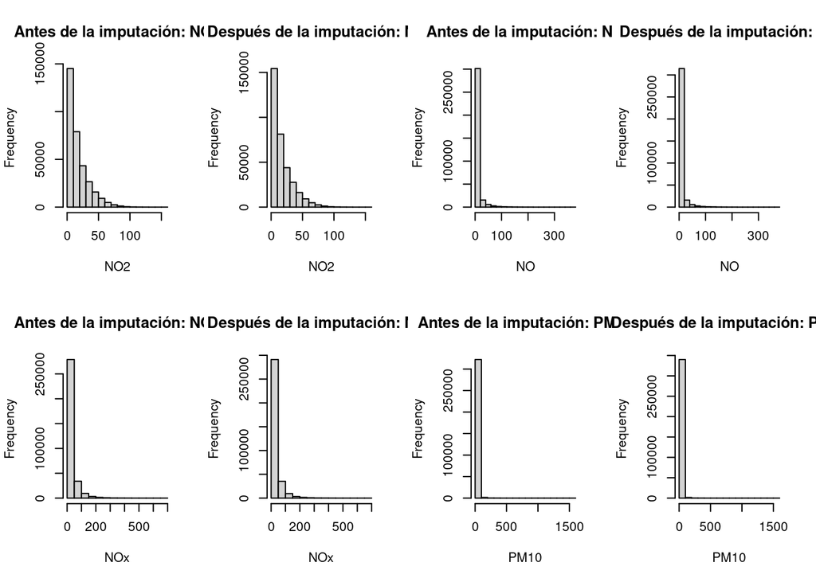

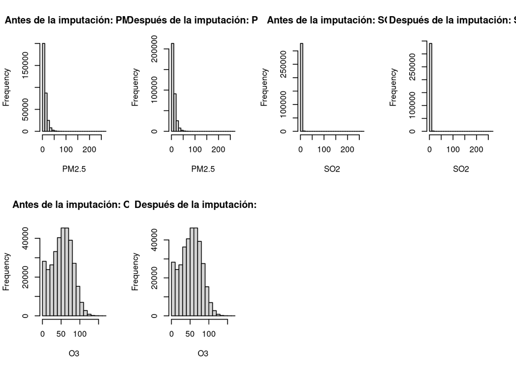

```r
contaminantes <- c("NO2", "NO", "NOx", "PM10", "PM2.5", "SO2", "O3")

# Comprobar la distribución de los contaminantes antes y después de la imputación
par(mfrow = c(2, 4))
for (contaminante in contaminantes) {
  # Histograma antes de la imputación
  hist(df[[contaminante]], main = paste("Antes de la imputación:", contaminante), xlab = contaminante)

  # Histograma después de la imputación
  hist(datos_limpios[[contaminante]], main = paste("Después de la imputación:", contaminante), xlab = contaminante)
}
```

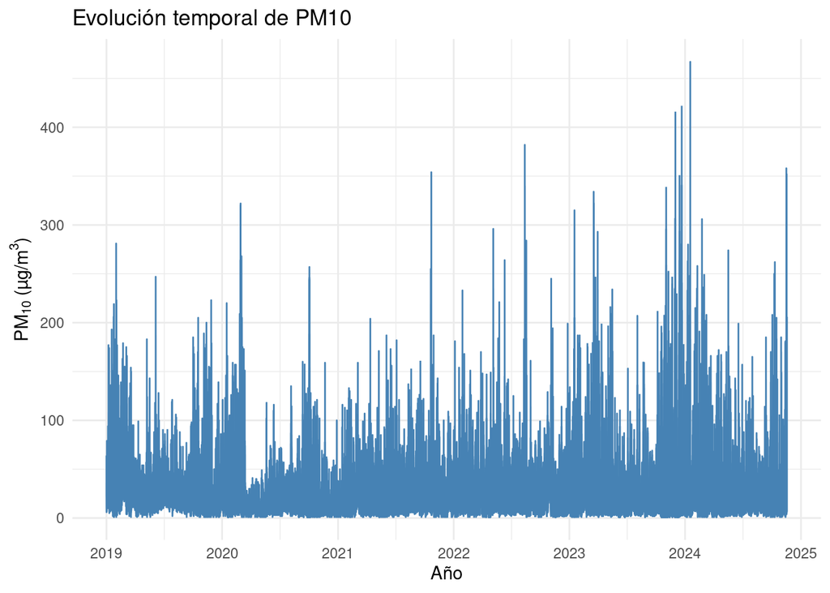

```r
# Quitamos la dana para que se vea mejor
df_sin_DANA <- subset(df, FechaHora < as.POSIXct("2024-11-17 18:00:00"))
datos_limpios_sin_DANA <- subset(datos_limpios, FechaHora < as.POSIXct("2024-11-17 18:00:00"))

ggplot(df_sin_DANA, aes(x = FechaHora, y = PM10, group = 1)) +
  geom_line(color = "steelblue") +
  scale_x_datetime(
    date_breaks = "1 year",
    date_labels = "%Y"
  ) +
  labs(
    title = "Evolución temporal de PM10",
    x     = "Año",
    y     = expression(PM[10]~"(µg/m"^3*")")
  ) +
  theme_minimal()
```

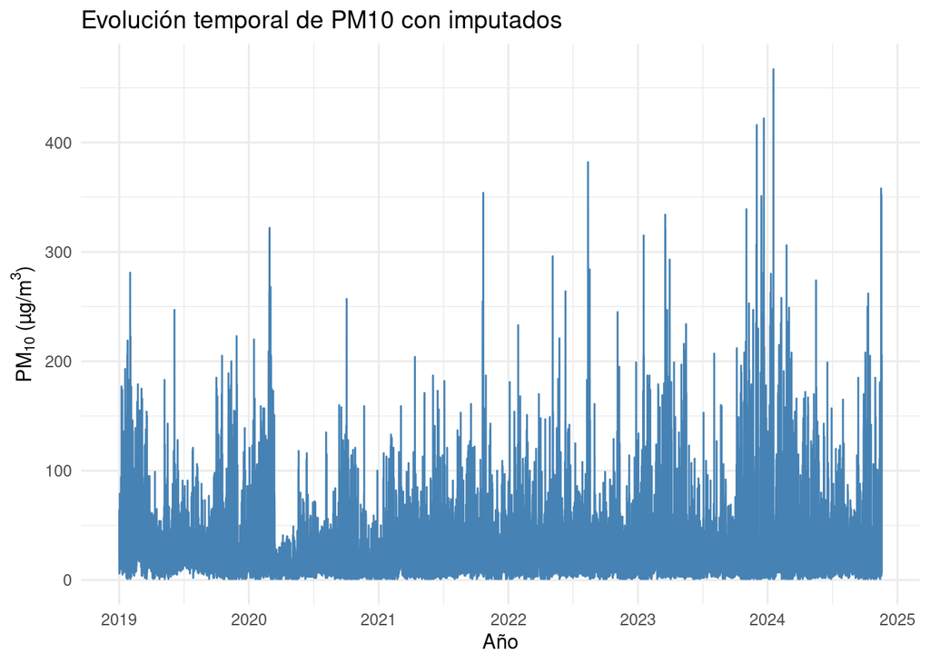

```r
# imputados
ggplot(datos_limpios_sin_DANA, aes(x = FechaHora, y = PM10, group = 1)) +
  geom_line(color = "steelblue") +
  scale_x_datetime(
    date_breaks = "1 year",
    date_labels = "%Y"
  ) +
  labs(
    title = "Evolución temporal de PM10 con imputados",
    x     = "Año",
    y     = expression(PM[10]~"(µg/m"^3*")")
  ) +
  theme_minimal()
```

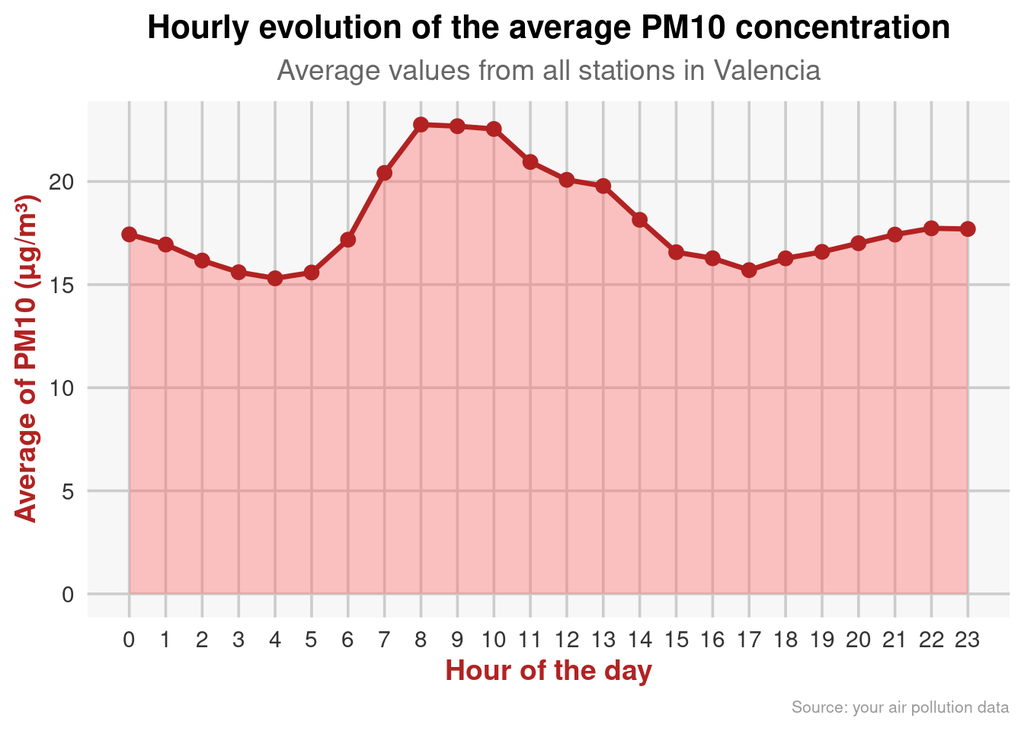

```r
df_sin_DANA <- df_sin_DANA %>%
  mutate(
    hora = hour(FechaHora))

datos_limpios_sin_DANA <- datos_limpios_sin_DANA %>%
  mutate(
    hora = hour(FechaHora))


df_hourly <- df_sin_DANA %>%
  group_by(hora) %>%
  summarise(media_PM10 = mean(PM10, na.rm = TRUE)) %>%
  mutate(Hora = as.numeric(as.character(hora))) %>%
  arrange(Hora)

ggplot(df_hourly, aes(x = hora, y = media_PM10)) +
  geom_area(fill = "#FF6E6E", alpha = 0.4) +
  geom_line(color = "#B22222", size = 1.2) +
  geom_point(color = "#B22222", size = 3) +
  scale_x_continuous(breaks = 0:23, limits = c(0, 23)) +
  labs(
    title    = "Hourly evolution of the average PM10 concentration",
    subtitle = "Average values from all stations in Valencia",
    x        = "Hour of the day",
    y        = "Average of PM10 (µg/m³)",
    caption  = "Source: your air pollution data"
  ) +
  theme_minimal(base_size = 14) +
  theme(
    plot.background   = element_rect(fill = "white", color = NA),
    panel.background  = element_rect(fill = "#f7f7f7", color = NA),
    panel.grid.major  = element_line(color = "gray80"),
    panel.grid.minor  = element_blank(),
    axis.title        = element_text(face = "bold", color = "#B22222"),
    axis.text         = element_text(color = "gray20"),
    plot.title        = element_text(face = "bold", size = 16, hjust = 0.5),
    plot.subtitle     = element_text(color = "gray40", hjust = 0.5),
    plot.caption      = element_text(size = 8, color = "gray60")
  )
```

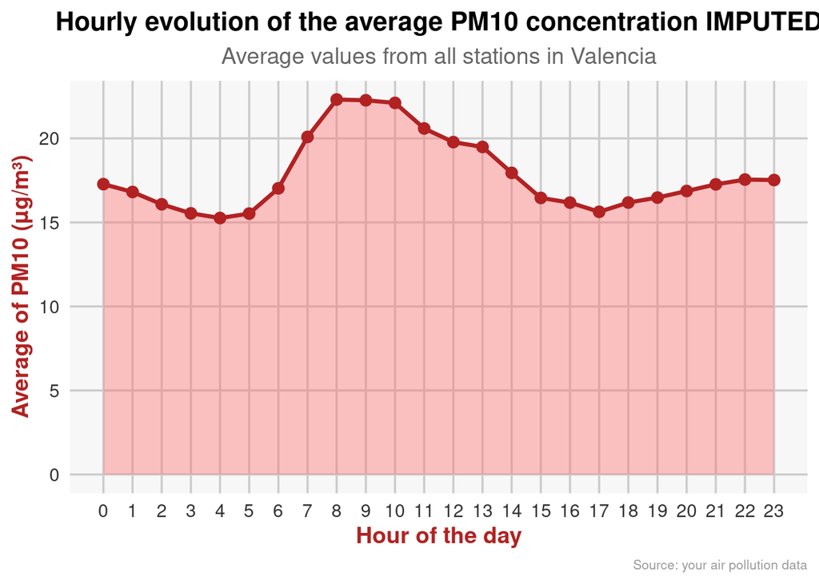

```r
#IMPUTADOS
df_hourly_limpio <- datos_limpios_sin_DANA %>%
  group_by(hora) %>%
  summarise(media_PM10 = mean(PM10, na.rm = TRUE)) %>%
  mutate(Hora = as.numeric(as.character(hora))) %>%
  arrange(Hora)

ggplot(df_hourly_limpio, aes(x = hora, y = media_PM10)) +
  geom_area(fill = "#FF6E6E", alpha = 0.4) +
  geom_line(color = "#B22222", size = 1.2) +
  geom_point(color = "#B22222", size = 3) +
  scale_x_continuous(breaks = 0:23, limits = c(0, 23)) +
  labs(
    title    = "Hourly evolution of the average PM10 concentration IMPUTED",
    subtitle = "Average values from all stations in Valencia",
    x        = "Hour of the day",
    y        = "Average of PM10 (µg/m³)",
    caption  = "Source: your air pollution data"
  ) +
  theme_minimal(base_size = 14) +
  theme(
    plot.background   = element_rect(fill = "white", color = NA),
    panel.background  = element_rect(fill = "#f7f7f7", color = NA),
    panel.grid.major  = element_line(color = "gray80"),
    panel.grid.minor  = element_blank(),
    axis.title        = element_text(face = "bold", color = "#B22222"),
    axis.text         = element_text(color = "gray20"),
    plot.title        = element_text(face = "bold", size = 16, hjust = 0.5),
    plot.subtitle     = element_text(color = "gray40", hjust = 0.5),
    plot.caption      = element_text(size = 8, color = "gray60")
  )
```

Observamos una muy ligera disminución, pero muy insignificante. Podemos concluir que la imputación ha sido correcta.

# 3 Comportamiento entre contaminantes

Para ver patrones entre contaminantes vamos a realizar, en primer lugar, un PCA. Dado que hemos imputado los faltantes, podemos usar cualquier modelo del PCA.

```r
# Creamos el df que usaremos en el PCA con las variables que nos interesan

df_pca <- datos_limpios %>% select(Origen, NO, NO2, NOx, O3, PM10, `PM2.5`, SO2)
```

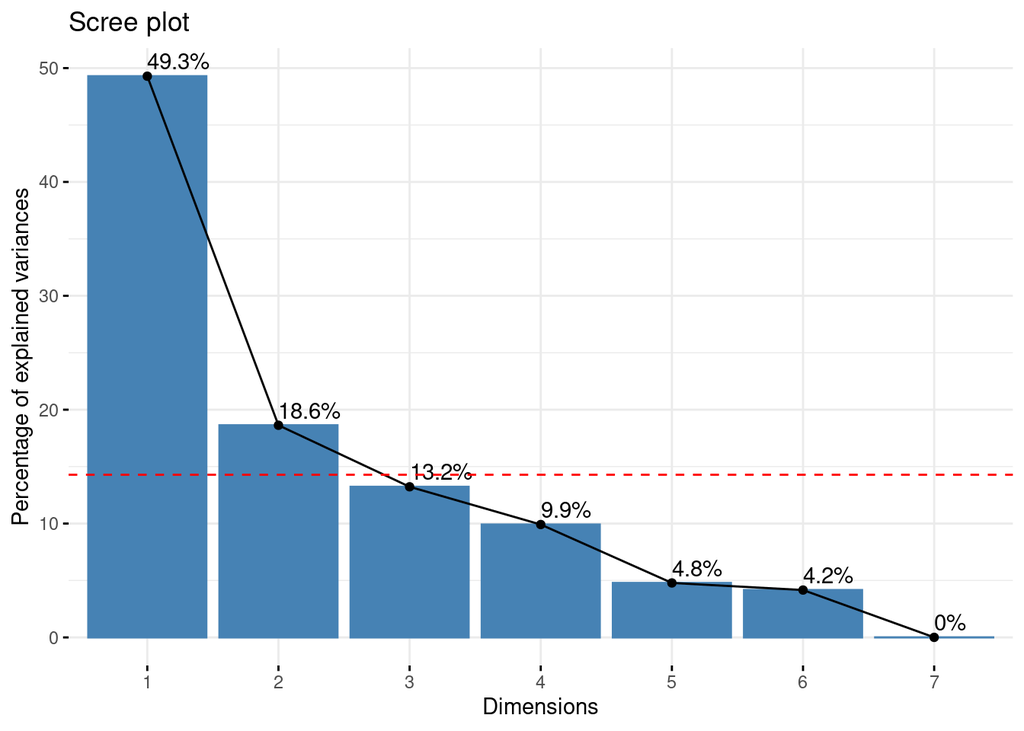

```r
set.seed(100)
res.pca <- PCA(df_pca,
               scale.unit = TRUE,
               ncp = 10,
               graph = FALSE,
               quali.sup = 'Origen')

# Visualizar varianza explicada
fviz_eig(res.pca, addlabels = TRUE) +
  geom_hline(yintercept = 100 / res.pca$call$ncp, linetype = 2, color = "red")
```

```r
eig.val <- get_eigenvalue(res.pca)
```

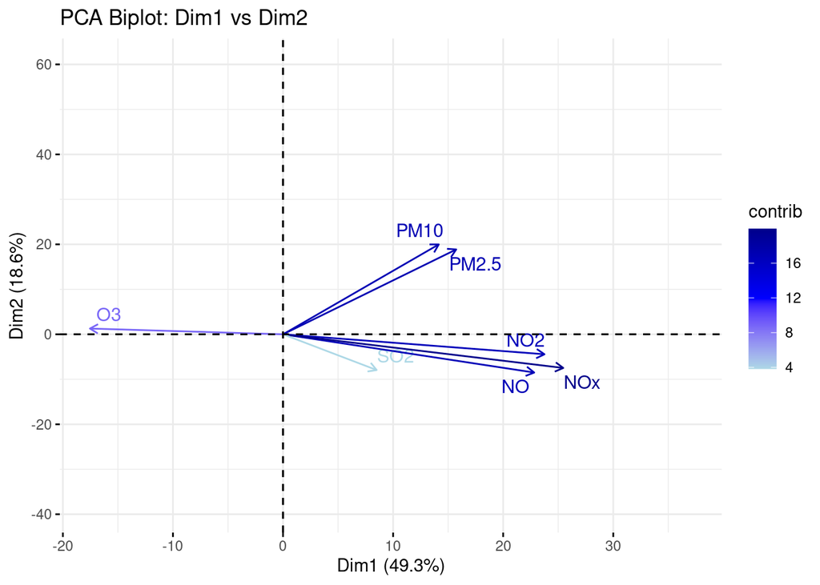

```r
set.seed(100)

fviz_pca_biplot(
  res.pca,
  axes        = c(1, 2),
  habillage   = "Origen",
  repel       = TRUE,
  label       = "var",
  invisible   = "ind",
  pointsize   = 1.5,
  col.var     = "contrib",
  gradient.cols = c("lightblue", "blue", "darkblue")
) +
  labs(
    title = "PCA Biplot: Dim1 vs Dim2"
  )
```

Como esperábamos, las variables $PM10$ y $PM2.5$ están fuertemente correlacionadas tanto en la componente 1 como en la 2. Estas dos variables también estan relacionadas con $NO$, $NO2$, y $NOx$ en la dimension 1, y con $SO2$ tambien pero mucho menos significante.

Explicación para dimensión 1:

- Las variables $PM10$ y $PM2.5$ están fuertemente correlacionadas entre sí.
- Las $NO$, $NO2$, y $NOx$ tambien estan fuertemente correlacionadas entre sí.
- La variable $SO2$ no parece verse muy afectada por la componente principal 1.
- Las variables $PM10$, $PM2.5$, $NO$, $NO2$, $NOx$ y $SO2$ estan correlacionadas pero $SO2$ menos significativamente.
- La variable $O3$ esta negativamente correlacionada con el resto de variables.

Estas relaciones estan justificadas, ya que tienen fuentes generadoras en común, por ejemplo la combustión en los automoviles. La relación con tráfico, la veremos más adelante.

La relacion de $O3$ esta justificada ya que reacciona con $NO$ en procesos fotoquímicos para generar $NO2$, por lo que cuanto más $NO$ y $NOx$ menos $O3$.

Explicación dimension 2:

En este caso sucede al reves que en la primera componente, lo cual podría deberse a muchos factores como por ejemplo, la meteorología ya que $NO$, $NO2$ y $NOx$ parece ser que se ve afectada por la temperatura segun hemos visto, pero se confirmara más adelante en el estudio con meteorologia.

Además se observa en las siguientes gráficas.

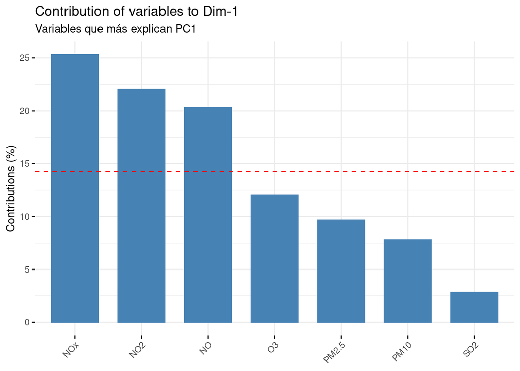

```r
fviz_contrib(
  res.pca,
  choice = "var",
  axes   = 1,
  top    = 7
) +
  labs(subtitle = "Variables que más explican PC1")
```

Las variables $NO$, $NO2$, y $NOx$ son las que más contribuyen a la primera componente. Los contaminantes $PM10$ y $PM2.5$ tambien contribuyen pero menos.

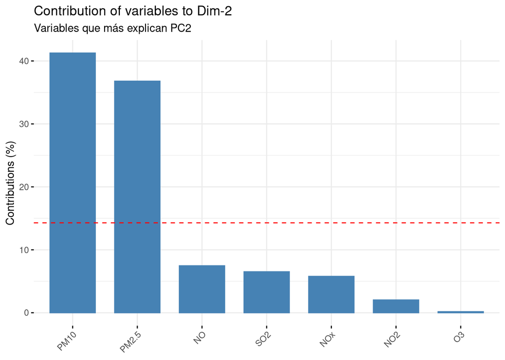

```r
fviz_contrib(
  res.pca,
  choice = "var",
  axes   = 2,
  top    = 7
) +
  labs(subtitle = "Variables que más explican PC2")
```

En la segunda componente las variables $PM10$ y $OM2.5$ son las que más contribuyen con diferencia.

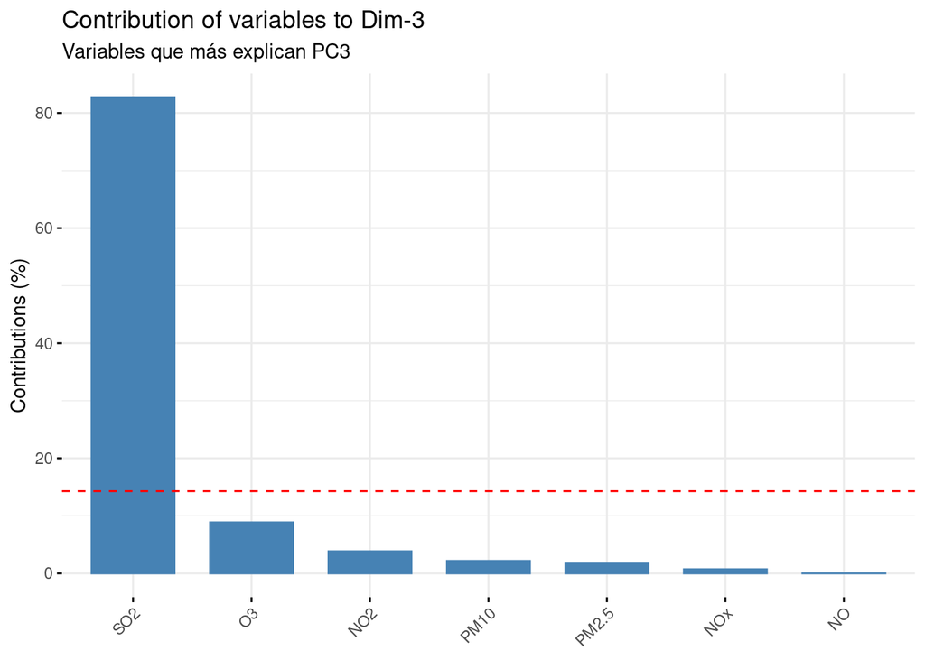

```r
fviz_contrib(
  res.pca,
  choice = "var",
  axes   = 3,
  top    = 7
) +
  labs(subtitle = "Variables que más explican PC3")
```

En la tercera componente la variable $SO2$ es la que más contribuye con mucha diferencia. Vamos a ver el biplot para CP1 y CP3.

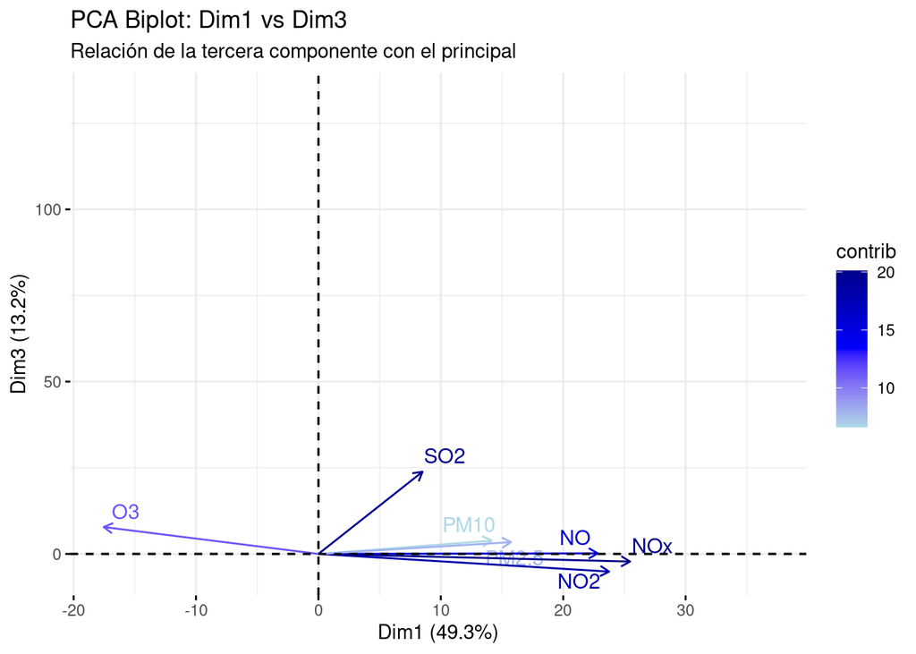

```r
set.seed(100)
fviz_pca_biplot(
  res.pca,
  axes        = c(1, 3),
  habillage   = "Origen",
  repel       = TRUE,
  label       = "var",
  invisible   = "ind",
  pointsize   = 1.5,
  col.var     = "contrib",
  gradient.cols = c("lightblue", "blue", "darkblue")
) +
  labs(
    title = "PCA Biplot: Dim1 vs Dim3",
    subtitle = "Relación de la tercera componente con el principal"
  )
```

Como habiamos visto, la variable $SO2$ tiene un loading alto en la dimensión 3, por lo que explica bastante la variailidad en esa componente. En este caso, podemos observar que todos los contaminantes estan correlacionados positivamente entre sí excepto el contaminante $O3$ que esta inversamente correlacionadas.

Ahora vamos a añadir los puntos de origen.

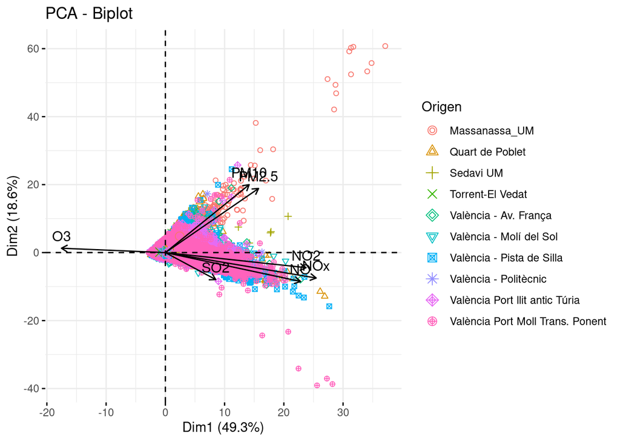

```r
set.seed(100)
fviz_pca_biplot(
  res.pca,
  habillage    = "Origen",
  addEllipses  = FALSE,
  repel        = FALSE,
  col.var       = "black",
  pointsize    = 1.5,
  label = "var"
)
```

Se observa que las zonas con combustion de vehiculos pesados (barcos, camiones, aviones,…) tienen valores mas elevados de NOs.

Se ve que los puntos están muy concentrados, pero con ligeras diferencias.

Vamos a hacer ahora el PCA agrupando las estaciones por su localización geográfica.

- Puerto: València - Av. França, València Port llit antic Túria, València Port Moll Trans. Ponent
- Extrarradio: Quart de Poblet, Torrent-El Vedat
- València - Molí del Sol
- València - Pista de Silla
- València - Politècnic

```r
set.seed(100)
df_pca_grp <- datos_limpios %>%
  mutate(
    Grupo = case_when(
      Origen %in% c(
        "València - Av. França",
        "València Port llit antic Túria",
        "València Port Moll Trans. Ponent"
      ) ~ "Puerto",
      Origen %in% c("Quart de Poblet", "Torrent-El Vedat") ~ "Extrarradio",
      Origen == c("València - Molí del Sol", "València - Pista de Silla", "València - Politècnic") ~ "Ciudad",
      TRUE                                          ~ NA_character_
    )
  ) %>%
  filter(!is.na(Grupo)) %>%
  select(Grupo, NO, NO2, NOx, O3, PM10, `PM2.5`, SO2)
```

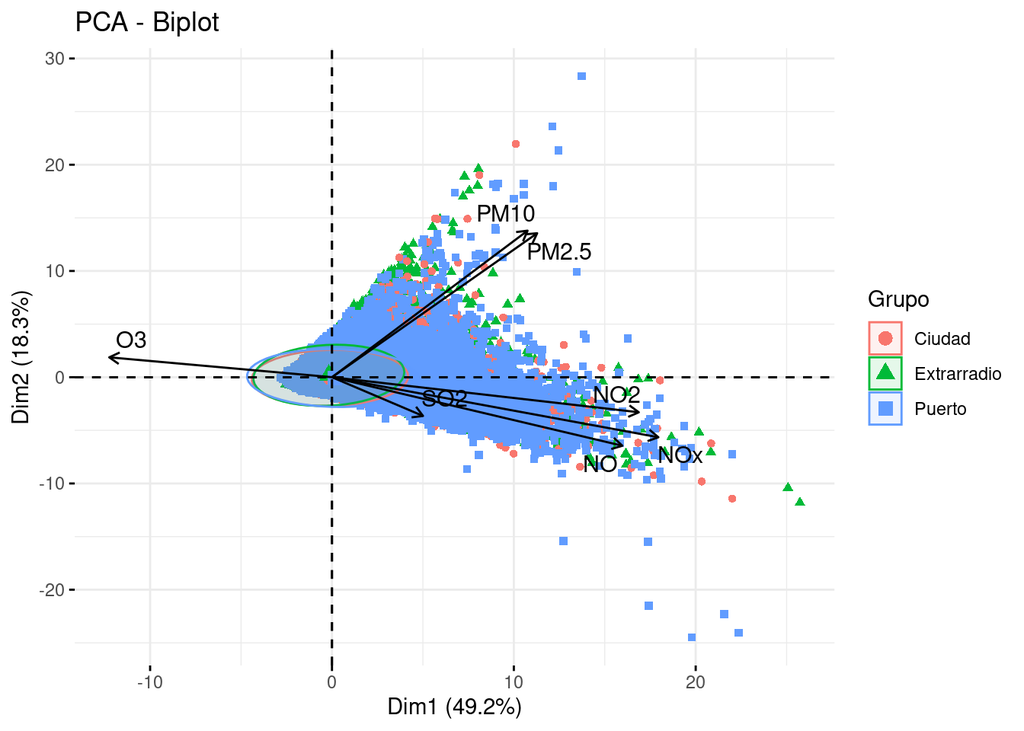

```r
# 2) PCA (Grupo como variable cuali.sup en la primera columna)
res.pca_grp <- PCA(
  df_pca_grp,
  quali.sup   = 1,
  scale.unit  = TRUE,
  graph       = FALSE
)


# 4) Biplot PC1 vs PC2 coloreado por Grupo
fviz_pca_biplot(
  res.pca_grp,
  axes        = c(1, 2),
  habillage    = "Grupo",
  addEllipses  = TRUE,
  ellipse.level = 0.95,
  col.var       = "black",
  repel        = TRUE,
  label        = "var"
)
```

Observamos más o menos lo mismo que antes. Las zonas de ‘puertos’ tienden a irse hacia la parte positiva de la PC1, lo que indica que tienden a generar más $PM10$, $PM2.5$, $NO$, $NO2$, $NOx$ y $SO2$. Las zonas en el extrarradio tienden a generar más $PM10$ y $PM2.5$. Pero en general todos están distribuidos similarmente.

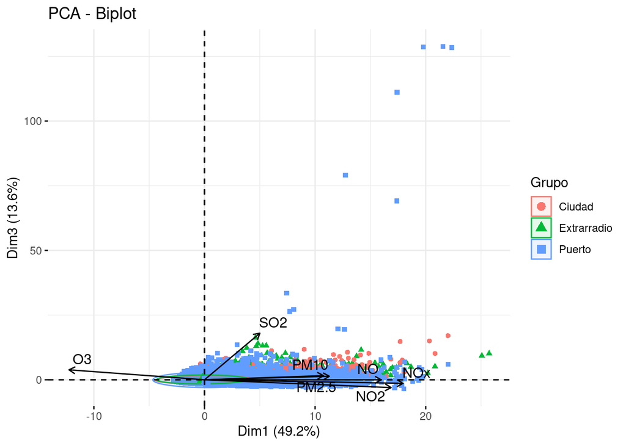

```r
set.seed(100)
fviz_pca_biplot(
  res.pca_grp,
  axes        = c(1, 3),
  habillage    = "Grupo",
  addEllipses  = TRUE,
  ellipse.level = 0.95,
  col.var       = "black",
  repel        = TRUE,
  label        = "var"
)
```

Parece ser que:

- La CP1 explica la combustión de fosiles, como tráfico, puerto,…. ya que se agrupan los contaminantes producidos por la combustión.
- La CP2 parece explicar algo de meteorología ya que se agrupan las variables que varian más con las estaciones del año.
- La CP3 no le vemos explicación.

Vamos a validar el modelo.

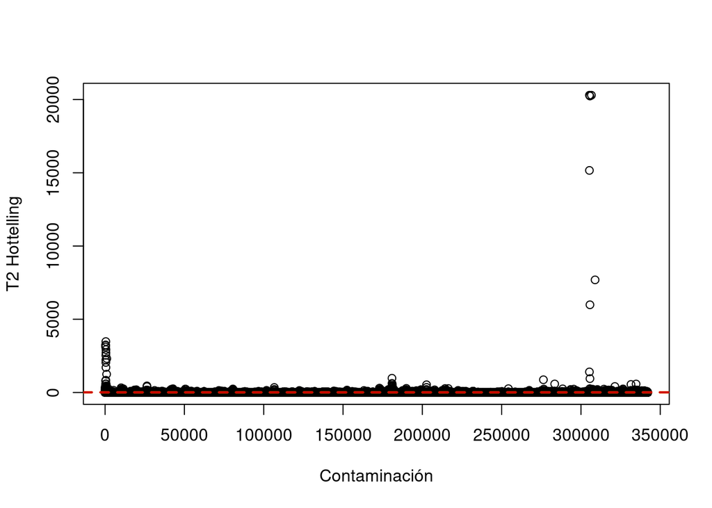

```r
set.seed(100)
K <- 3

res.pca <- PCA(df_pca,
               scale.unit = TRUE,
               graph = FALSE,
               ncp = K,
               quali.sup = which(names(df_pca) == "Origen"))

misScores = res.pca$ind$coord[,1:K]
miT2 = colSums(t(misScores**2)/eig.val[1:K,1])
I = nrow(df_pca)
F95 = K*(I**2 - 1)/(I*(I - K)) * qf(0.95, K, I-K)
F99 = K*(I**2 - 1)/(I*(I - K)) * qf(0.99, K, I-K)

plot(1:length(miT2), miT2, type = "p", xlab = "Contaminación", ylab = "T2 Hottelling")
abline(h = F95, col = "orange", lty = 2, lwd = 2)
abline(h = F99, col = "red3", lty = 2, lwd = 2)
```

Observamos que la gran mayoría de los puntos se encuentra por debajo de esta línea, lo que indica que esas combinaciones de contaminantes se consideran normales dentro de la variabilidad esperada. En cambio, hay un número razonable de observaciones que superan el umbral: esos valores atípicos señalan episodios extremos o inusuales de contaminación, ya sea por picos puntuales de emisión o por condiciones meteorológicas excepcionales.

```r
idx_max_anomalia <- which.max(miT2)

# Mostrar el valor de T² más alto
miT2[idx_max_anomalia]
```

```
##   305328
## 20297.52
```

```r
# Mostrar la fila correspondiente en los datos originales
df[idx_max_anomalia, ]
```

```
## # A tibble: 1 × 9
##   FechaHora           Origen              NO   NO2   NOx    O3  PM10 PM2.5   SO2
##   <dttm>              <fct>            <int> <int> <int> <int> <int> <int> <int>
## 1 2021-03-06 16:00:00 València - Poli…     1     3     4    64    17    16     4
```

# 4 Clustering

Ahora vamos a hacer un clustering.

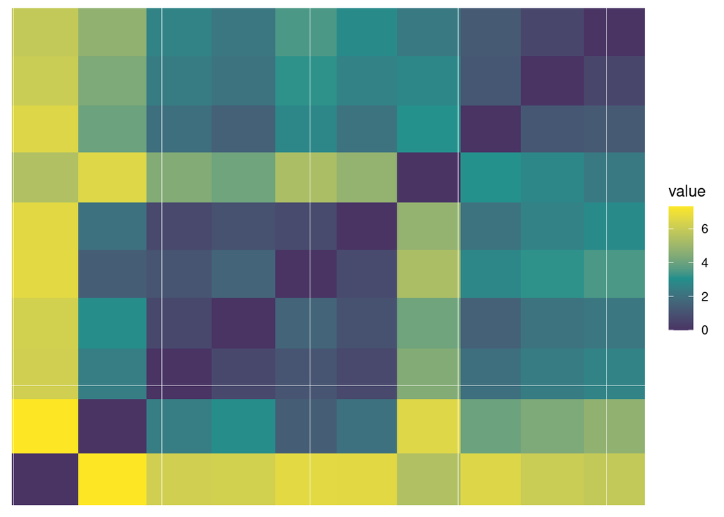

```r
# 1) Agregar la concentración media de cada contaminante por estación
df_sta <- datos_limpios %>%
  group_by(Origen) %>%
  summarise(across(
    c(NO, NO2, NOx, O3, PM10, `PM2.5`, SO2),
    ~ mean(.x, na.rm = TRUE)
  )) %>%
  column_to_rownames("Origen")

# 2) Escalar los datos
df_scaled <- scale(df_sta)

# Convertir matriz a data frame antes de usar sample_n
vars_sample <- as.data.frame(df_scaled) %>% sample_n(2000, replace = TRUE)

# Calcular la matriz de distancias (opcional: usar scale() si hace falta)
midist <- get_dist(scale(vars_sample), method = "euclidean")

# Visualizar la matriz
fviz_dist(midist,
          show_labels = FALSE,
          lab_size = 0.3,
          gradient = list(low = "#440154", mid = "#21908C", high = "#FDE725"))
```

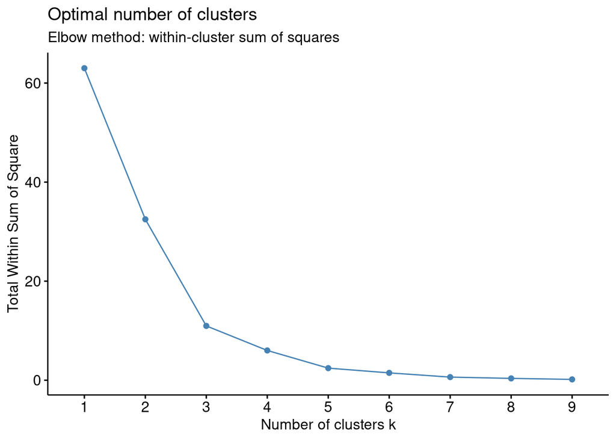

```r
# 1) Medias de contaminantes por estación
df_sta <- datos_limpios %>%
  group_by(Origen) %>%
  summarise(
    NO    = mean(NO,    na.rm = TRUE),
    NO2   = mean(NO2,   na.rm = TRUE),
    NOx   = mean(NOx,   na.rm = TRUE),
    O3    = mean(O3,    na.rm = TRUE),
    PM10  = mean(PM10,  na.rm = TRUE),
    PM2.5 = mean(`PM2.5`, na.rm = TRUE),
    SO2   = mean(SO2,   na.rm = TRUE)
  ) %>%
  column_to_rownames("Origen")

# 2) Escalado (media=0, sd=1)
df_scaled <- scale(df_sta)

# 3) Rango de k a probar (n estaciones - 1, o hasta 10)
n_stations <- nrow(df_scaled)
max_k      <- min(10, n_stations - 1)

# 4a) Elbow method (WSS)
fviz_nbclust(
  df_scaled,
  FUNcluster = kmeans,
  method     = "wss",
  k.max      = max_k,
  nstart     = 25
) +
  labs(subtitle = "Elbow method: within‐cluster sum of squares")
```

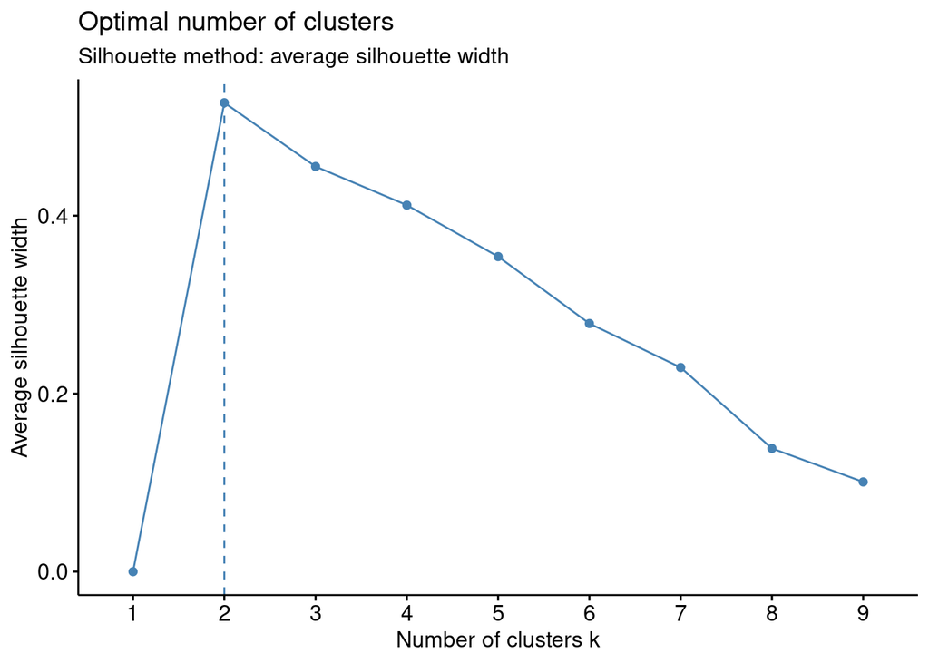

```r
# 4b) Silhouette method
fviz_nbclust(
  df_scaled,
  FUNcluster = kmeans,
  method     = "silhouette",
  k.max      = max_k,
  nstart     = 25
) +
  labs(subtitle = "Silhouette method: average silhouette width")
```

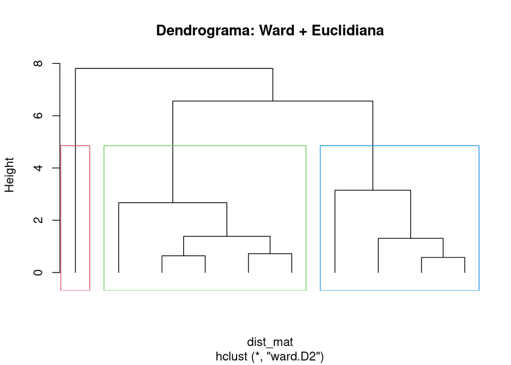

```r
# 5) Clustering jerárquico (distancia Euclídea + Ward)
dist_mat <- dist(df_scaled, method = "euclidean")
hc       <- hclust(dist_mat,    method = "ward.D2")

# 6) Elegir k
k_opt <- 3

# 7) Cortar el árbol y extraer clusters
station_clusters <- cutree(hc, k = k_opt)

# 8) Data.frame de etiquetas por estación
station_clusters_df <- data.frame(
  Origen  = names(station_clusters),
  cluster = factor(station_clusters)
)

# 9) Unir etiquetas al dataset original
datos_clustered <- datos_limpios %>%
  left_join(station_clusters_df, by = "Origen")

# 10) Dendrograma con cortes marcados
plot(hc,
     labels = FALSE,
     hang   = -1,
     main   = "Dendrograma: Ward + Euclidiana")
rect.hclust(hc, k = k_opt, border = 2:(k_opt+1))
```

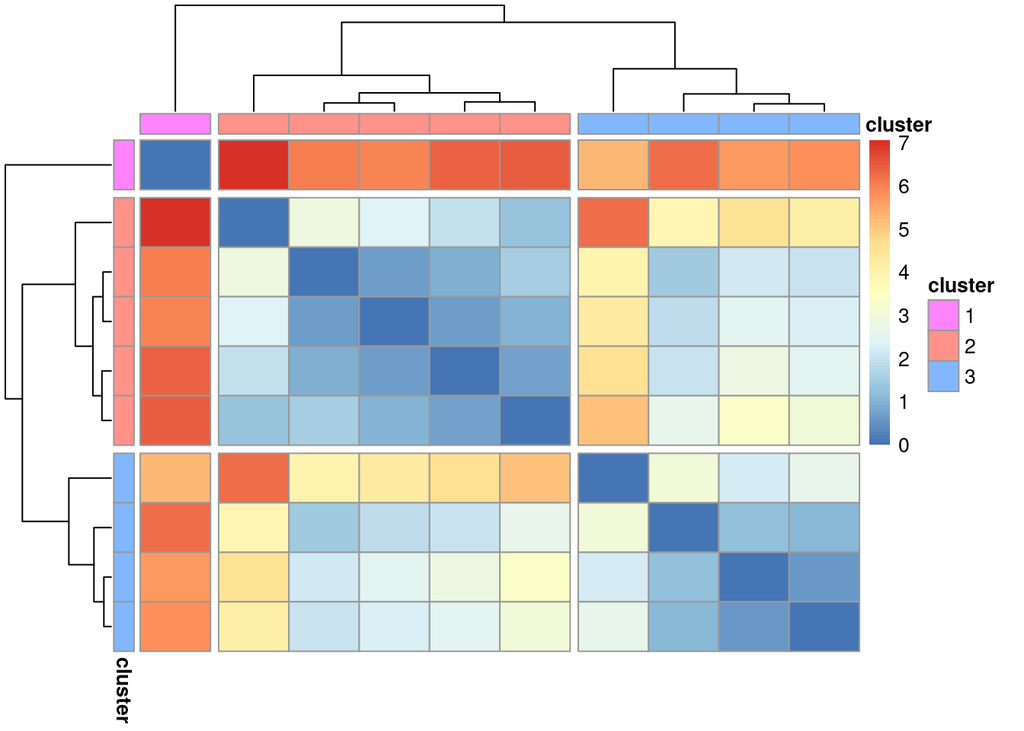

```r
rownames(station_clusters_df) <- NULL

annotation <- station_clusters_df %>%
  column_to_rownames("Origen")

# Llamada a pheatmap
pheatmap(
  as.matrix(dist_mat),
  clustering_distance_rows   = dist_mat,
  clustering_distance_cols   = dist_mat,
  clustering_method          = "ward.D2",
  cutree_rows                = k_opt,
  cutree_cols                = k_opt,
  annotation_row             = annotation,
  annotation_col             = annotation,
  show_rownames              = FALSE,
  show_colnames              = FALSE
)
```

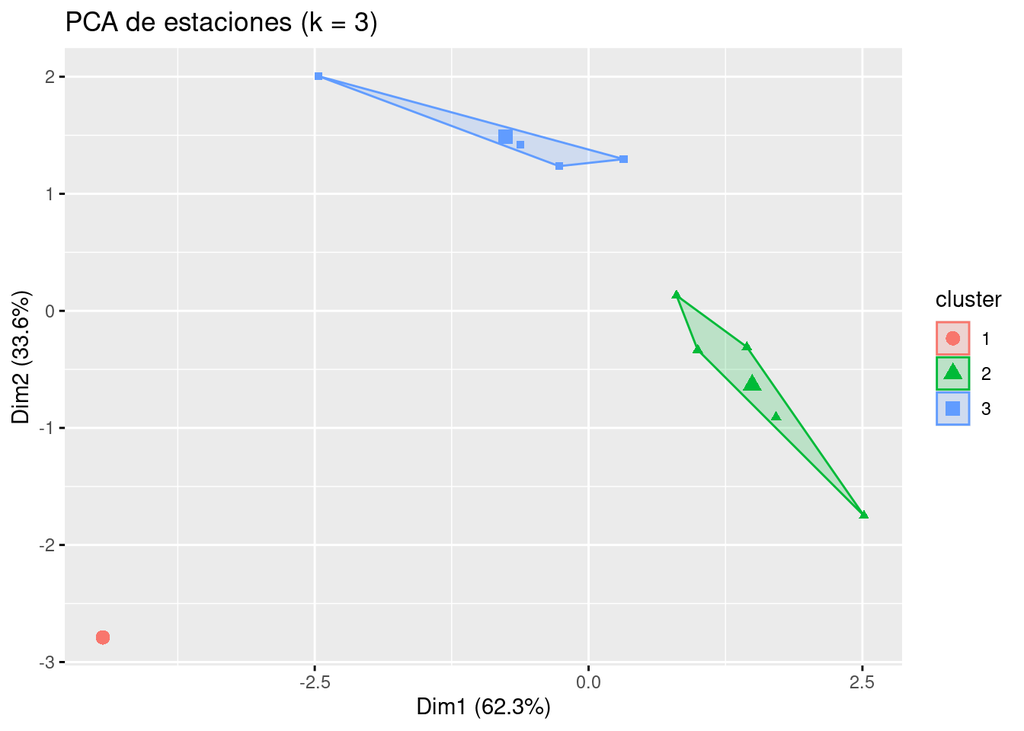

```r
# 11) Proyección PCA coloreada por cluster
fviz_cluster(
  list(data    = df_scaled,
       cluster = station_clusters),
  geom            = "point",
  ellipse         = TRUE,
  show.clust.cent = TRUE
) +
  labs(title = paste0("PCA de estaciones (k = ", k_opt, ")"))
```

```r
# 12) Centros de cada cluster en las unidades originales
centers_unscaled <- df_sta
centers_unscaled$cluster <- station_clusters[rownames(centers_unscaled)]
centers_summary <- centers_unscaled %>%
  as.data.frame() %>%
  group_by(cluster) %>%
  summarise(
    NO    = mean(NO),
    NO2   = mean(NO2),
    NOx   = mean(NOx),
    O3    = mean(O3),
    PM10  = mean(PM10),
    PM2.5 = mean(PM2.5),
    SO2   = mean(SO2)
  )

print(centers_summary)
```

```
## # A tibble: 3 × 8
##   cluster    NO   NO2   NOx    O3  PM10 PM2.5   SO2
##     <int> <dbl> <dbl> <dbl> <dbl> <dbl> <dbl> <dbl>
## 1       1 10.3   19.1  34.7  25.5 129.   25.3  1.06
## 2       2  4.33  13.9  20.3  53.6  17.5  10.6  3.61
## 3       3 12.6   24.2  43.4  46.4  21.2  10.6  3.39
```

Hemos seleccionado 3 clusters ya que creemos que es la mejor combinación, ya que el 3 tiene el coeficiente de silhouette 2º más alto y por el metodo del codo vemos que en el cluster 3/4 se observa la diferencia.

```r
station_clusters_df %>%
  arrange(cluster) %>%
  group_by(cluster) %>%
  summarise(
    estaciones = paste(Origen, collapse = ", ")
  )
```

```
## # A tibble: 3 × 2
##   cluster estaciones
##   <fct>   <chr>
## 1 1       Massanassa_UM
## 2 2       Quart de Poblet, Torrent-El Vedat, València - Av. França, València - …
## 3 3       Sedavi UM, València - Pista de Silla, València Port llit antic Túria,…
```

```r
station_clusters_df
```

```
##                              Origen cluster
## 1                     Massanassa_UM       1
## 2                   Quart de Poblet       2
## 3                         Sedavi UM       3
## 4                  Torrent-El Vedat       2
## 5             València - Av. França       2
## 6           València - Molí del Sol       2
## 7         València - Pista de Silla       3
## 8             València - Politècnic       2
## 9    València Port llit antic Túria       3
## 10 València Port Moll Trans. Ponent       3
```

Aqui vemos en que clusters se ha asignado cada estación de medición.